# playing_with_brms

Milla Juntunen

2022-07-18

```r
#require(brms)
#require(ggplot2)
#require(gdata)
#require(dplyr)
#require(parallel)
#require(cowplot)
```

```r
library("brms")
library("gdata")
```

```r
library("readxl")
library("ggplot2")
library("dplyr")
library("parallel")
library("cowplot")
```

This code tries to use brm() to model the mortality rate after prehospital blood transfusion (PHBT). Because the creator of this code is not yet capable of using this tool, this code is more about playing with the data and trying to learn how this works (no success so far). In other words, this code is a work in process, and it doesn’t probably give any reasonable results about anything.

First trying to get something done. Using code found from the internet (see https://tem11010.github.io/regression_brms/). They did some plotting to start playing with this:

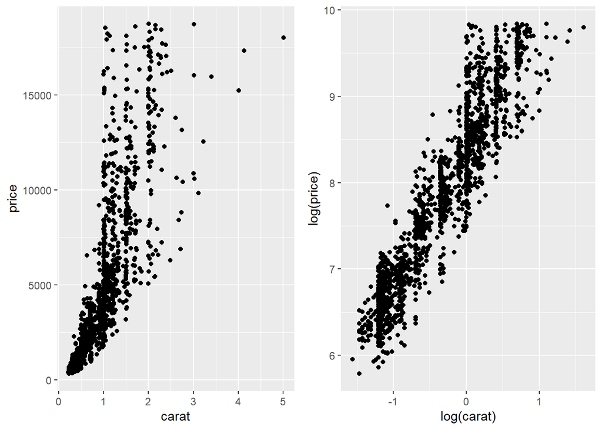

```r
set.seed(2018)
data(diamonds)

diamonds.full <- na.omit(diamonds) %>% drop.levels # remove missing data
diamonds.full$rows <- as.numeric(rownames(diamonds.full))
diamonds.train <- diamonds.full %>% group_by(color, clarity) %>% sample_n(size = 30) # subset
diamonds.keep <-   filter(diamonds.full, !rows %in% diamonds.train$rows)

# remove row in training set
diamonds.test <- diamonds.keep[sample(nrow(diamonds.keep), 20000), ]

# get rid of zero values and outliers
diamonds.train <- diamonds.train %>% filter( x> 0, y >0, z > 0, price > 0, price < max(diamonds$price))
diamonds.test <- diamonds.test %>% filter( x> 0, y >0, z > 0, price > 0, price < max(diamonds$price))


plot_grid(

  ggplot()+
    geom_point(data = diamonds.train, aes(y = price, x = carat))+
    geom_smooth(),

  ggplot()+
    geom_point(data = diamonds.train, aes(y = log(price), x = log(carat)))+
    geom_smooth(), ncol = 2
  )
```

For some reason (it was not explained in the article), they used log(y) ~ log(x). Would be nice to know why they did so…

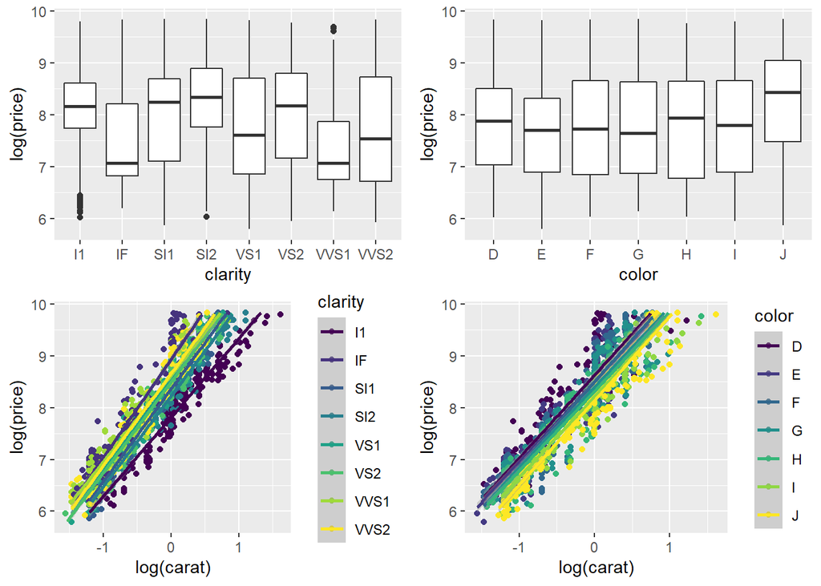

```r
plot_grid(

  ggplot(data = diamonds.train, aes(y = log(price), x = clarity)) + geom_boxplot(),

  ggplot(data = diamonds.train, aes(y = log(price), x = color)) + geom_boxplot(),

  ggplot(data = diamonds.train, aes(y = log(price), x = log(carat), color = clarity)) +
         geom_point() + geom_smooth(method = "lm") +
         ylim(c(min(log(diamonds$price)),  max(log(diamonds$price)))),

  ggplot(data = diamonds.train, aes(y = log(price), x = log(carat), color = color)) +
         geom_point() + geom_smooth(method = "lm") +
         ylim(c(min(log(diamonds$price)), max(log(diamonds$price)))),

  ncol = 2)
```

Finally using the actual tool:

```r
#Testing with diamonds data if this works at all
brm.dia <- brm(log(price) ~ log(carat),
             brmsfamily(family = "Gamma", link = "log"),
             data = na.omit(diamonds.train),
             chains = 4, #specify the number of Markov chains
             cores = getOption("mc.cores", 1),
             iter = 3000, warmup = 1500, thin = 5,

             prior =  c(prior(normal(0, 3), "b"), # set normal prior on regression coefficients (mean of 0, location of 3)

                        prior(normal(0, 3), "Intercept"))) # set normal prior on intercept (mean of 0, location of 3)
```

Plotting the results about diamond data:

```r
summary(brm.dia)
```

```
##  Family: gamma
##   Links: mu = log; shape = identity
## Formula: log(price) ~ log(carat)
##    Data: na.omit(diamonds.train) (Number of observations: 1680)
##   Draws: 4 chains, each with iter = 3000; warmup = 1500; thin = 5;
##          total post-warmup draws = 1200
##
## Population-Level Effects:
##           Estimate Est.Error l-95% CI u-95% CI Rhat Bulk_ESS Tail_ESS
## Intercept     2.12      0.00     2.12     2.12 1.00     1133     1244
## logcarat      0.19      0.00     0.19     0.20 1.00     1402     1133
##
## Family Specific Parameters:
##       Estimate Est.Error l-95% CI u-95% CI Rhat Bulk_ESS Tail_ESS
## shape   447.03     15.12   416.58   475.74 1.01     1189     1121
##
## Draws were sampled using sampling(NUTS). For each parameter, Bulk_ESS
## and Tail_ESS are effective sample size measures, and Rhat is the potential
## scale reduction factor on split chains (at convergence, Rhat = 1).
```

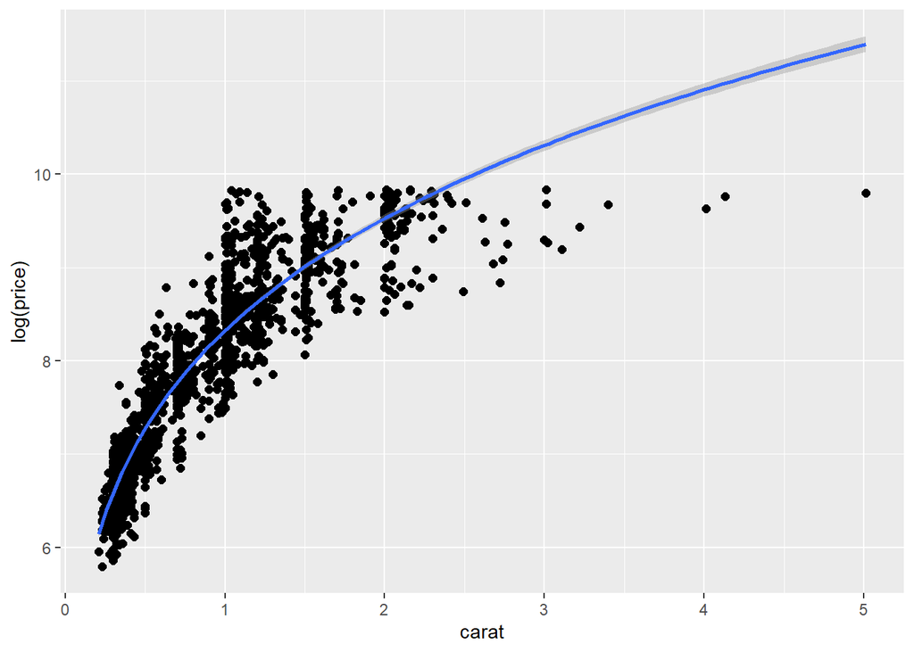

```r
plot(conditional_effects(brm.dia),points=T)
```

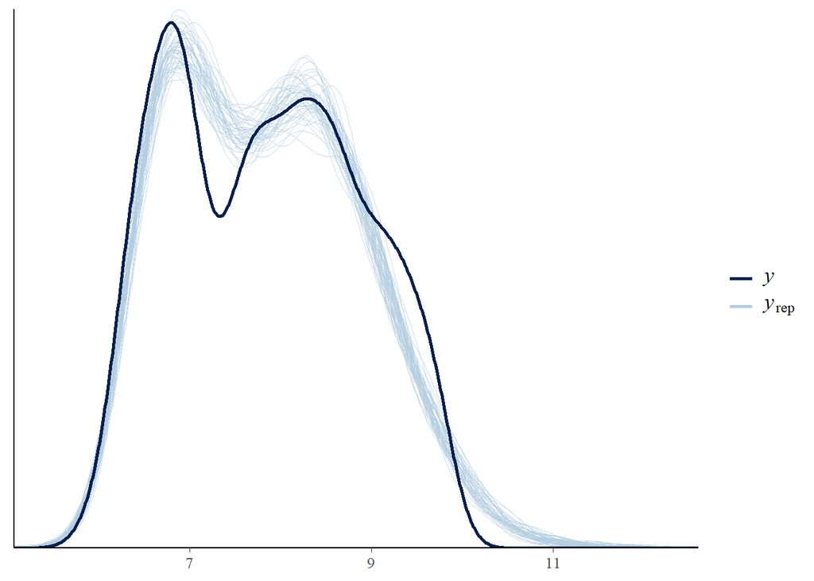

```r
pp_check(brm.dia, ndraws = 50)
```

Now trying to do something similar with PHBT data. Using all of the products at the same time. Time is in minutes, mortality rate is a decimal number Using mortality ~ log(time) since in every other way it crashes with million errors… Should probably do something for the intercept too, I guess it should be (somewhere near) zero.

```r
# Now trying own data

# Reading the data from excel (time in minutes)
df <- read_excel("C:\\Projektit\\whole_blood_research\\excel\\Emergencyprocess_PHBT_splines.xlsx", sheet = "Sheet1")
all_data <- filter(df, products == "O-negative PRBCs" | products == "LTOWB" | products == "plasma and/or RBCs")

#brm <- brm(log(mortality) ~ log(time),
             #brmsfamily(family = "Gamma", link = "log"),
             #data = all_data,
             #chains = 4,
             #cores = getOption("mc.cores", 1),
             #iter = 3000, warmup = 1500, thin = 5,

             #prior =  c(prior(normal(0, 2), "b"),
                        #prior(normal(0, 2), "Intercept"),
                        #prior(gamma(0.01,0.01),class="shape")))
```

“Error: Family ‘gamma’ requires response greater than 0.” Well. That is interesting. Don’t really know how to prevent this. Trying something else instead… using y ~ x:

```r
brm <- brm(mortality ~ time,
             brmsfamily(family = "Gamma", link = "log"),
             data = all_data,
             chains = 4,
             cores = getOption("mc.cores", 1),
             iter = 3000, warmup = 1500, thin = 5,

             prior =  c(prior(normal(0, 2), "b"),
                        prior(normal(0, 2), "Intercept"),
                        prior(gamma(0.01,0.01),class="shape")))
```

```
##
##
## Error in sampler$call_sampler(args_list[[i]]) : Initialization failed.
## character(0)
## [1] "error occurred during calling the sampler; sampling not done"
```

Doesn’t seem to be working. Trying to use y ~ log(x), it worked in gml() (don’t know why though :D)

```r
brm.1 <- brm(mortality ~ log(time),
             brmsfamily(family = "Gamma", link = "log"),
             data = all_data,
             chains = 4,
             cores = getOption("mc.cores", 1),
             iter = 3000, warmup = 1500, thin = 5,

             prior =  c(prior(normal(0, 2), "b"),
                        prior(normal(0, 2), "Intercept"),
                        prior(gamma(0.01,0.01),class="shape")))
```

Getting some information of the results (not quite sure how to interpret these, should check it out)

```r
summary(brm.1)
```

```
##  Family: gamma
##   Links: mu = log; shape = identity
## Formula: mortality ~ log(time)
##    Data: all_data (Number of observations: 17)
##   Draws: 4 chains, each with iter = 3000; warmup = 1500; thin = 5;
##          total post-warmup draws = 1200
##
## Population-Level Effects:
##           Estimate Est.Error l-95% CI u-95% CI Rhat Bulk_ESS Tail_ESS
## Intercept    -3.18      0.46    -4.08    -2.22 1.00     1242     1079
## logtime       0.18      0.06     0.06     0.30 1.00     1254     1163
##
## Family Specific Parameters:
##       Estimate Est.Error l-95% CI u-95% CI Rhat Bulk_ESS Tail_ESS
## shape     5.25      1.75     2.30     9.04 1.00     1019     1015
##
## Draws were sampled using sampling(NUTS). For each parameter, Bulk_ESS
## and Tail_ESS are effective sample size measures, and Rhat is the potential
## scale reduction factor on split chains (at convergence, Rhat = 1).
```

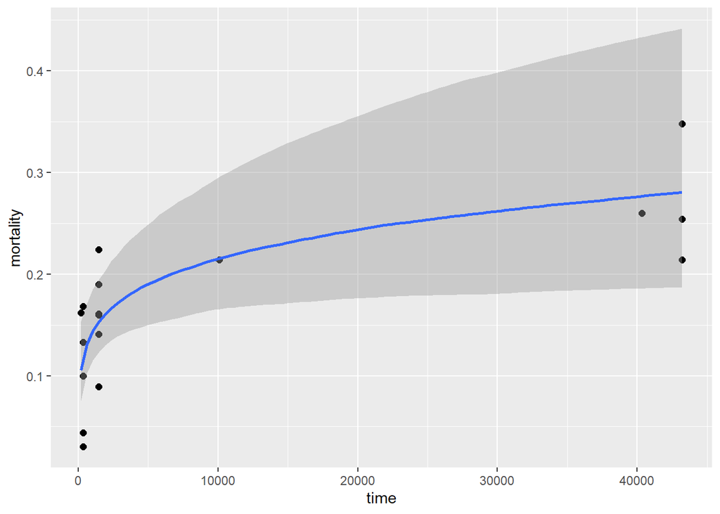

```r
plot(conditional_effects(brm.1),points=T)
```

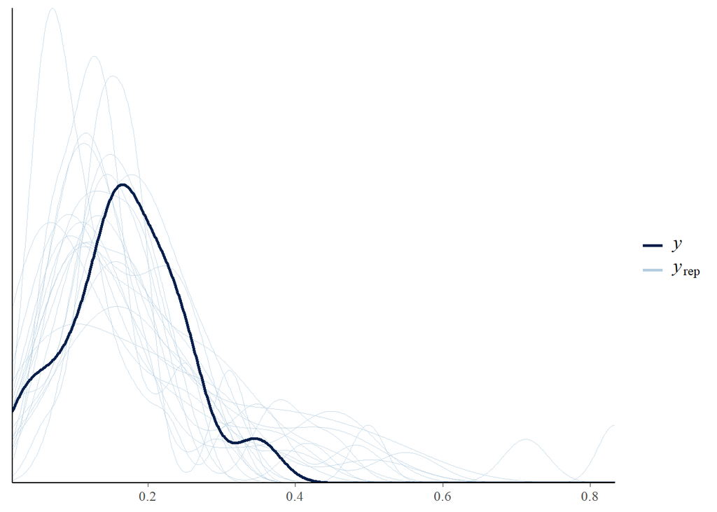

```r
pp_check(brm.1, ndraws = 20)
```

Well the intercept is bad, I bet there is going to be negative mortality near zero. And those plots are not good either, compared how those looked in the example. Trying to force the intercept to 0, no idea if this is okay or not (trying anyway). Tried to do like in here: http://paul-buerkner.github.io/brms/reference/set_prior.html

```r
brm.force.zero <- brm(mortality ~ 0+0+log(time),
             brmsfamily(family = "Gamma", link = "log"),
             data = all_data,
             chains = 4,
             cores = getOption("mc.cores", 1),
             iter = 3000, warmup = 1500, thin = 5,

             prior =  c(prior(normal(0, 2), "b"),
                        #prior(normal(0, 2), "Intercept"),
                        prior(gamma(0.01,0.01),class="shape")))
summary(brm.force.zero)
```

```
##  Family: gamma
##   Links: mu = log; shape = identity
## Formula: mortality ~ 0 + 0 + log(time)
##    Data: all_data (Number of observations: 17)
##   Draws: 4 chains, each with iter = 3000; warmup = 1500; thin = 5;
##          total post-warmup draws = 1200
##
## Population-Level Effects:
##         Estimate Est.Error l-95% CI u-95% CI Rhat Bulk_ESS Tail_ESS
## logtime    -0.18      0.03    -0.23    -0.13 1.00     1298     1128
##
## Family Specific Parameters:
##       Estimate Est.Error l-95% CI u-95% CI Rhat Bulk_ESS Tail_ESS
## shape     1.54      0.51     0.66     2.72 1.00     1169     1103
##
## Draws were sampled using sampling(NUTS). For each parameter, Bulk_ESS
## and Tail_ESS are effective sample size measures, and Rhat is the potential
## scale reduction factor on split chains (at convergence, Rhat = 1).
```

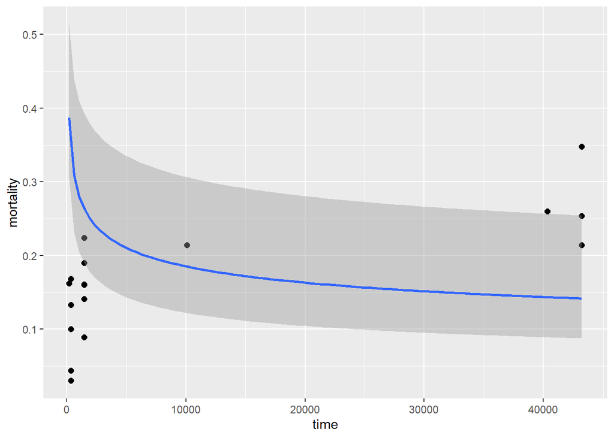

```r
plot(conditional_effects(brm.force.zero),points=T)
```

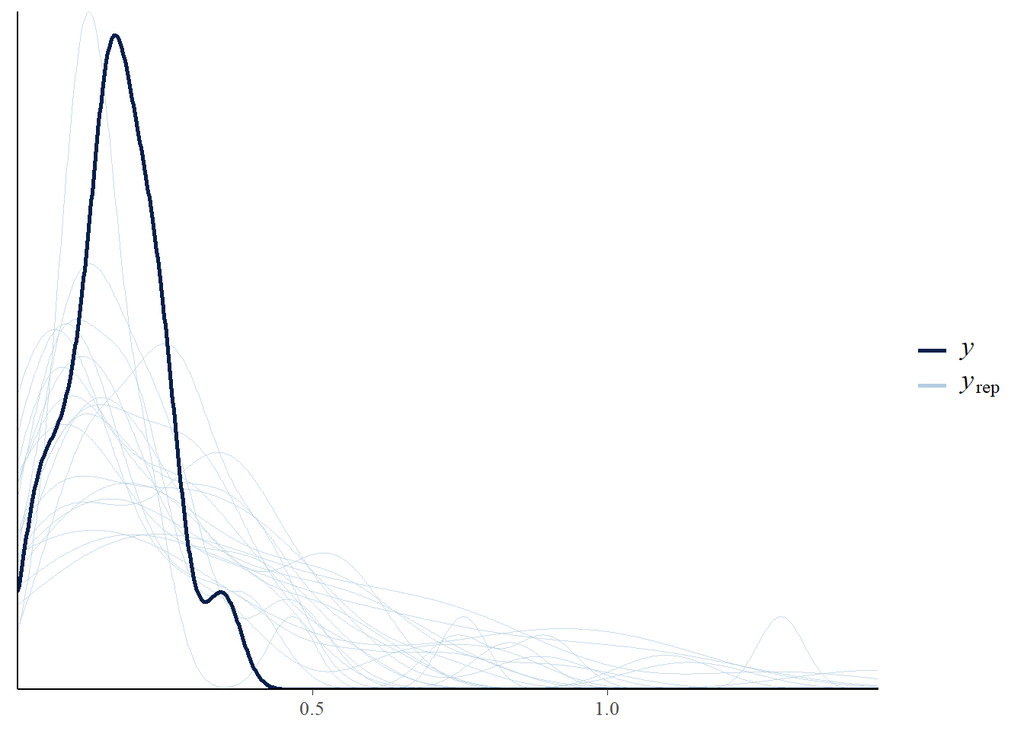

```r
pp_check(brm.force.zero, ndraws = 20)
```

That’s even more horrible than the first one. Don’t know why it looks like that… Trying to change the values in the intercept. My best guess is that this might get it closer to 0:

```r
brm.intercept.test <- brm(mortality ~ log(time),
             brmsfamily(family = "Gamma", link = "log"),
             data = all_data,
             chains = 4,
             cores = getOption("mc.cores", 1),
             iter = 3000, warmup = 1500, thin = 5,

             prior =  c(prior(normal(0, 2), "b"),
                        prior(normal(1, 0.01), "Intercept"),
                        prior(gamma(0.01,0.01),class="shape")))
summary(brm.intercept.test)
```

```
##  Family: gamma
##   Links: mu = log; shape = identity
## Formula: mortality ~ log(time)
##    Data: all_data (Number of observations: 17)
##   Draws: 4 chains, each with iter = 3000; warmup = 1500; thin = 5;
##          total post-warmup draws = 1200
##
## Population-Level Effects:
##           Estimate Est.Error l-95% CI u-95% CI Rhat Bulk_ESS Tail_ESS
## Intercept    -1.22      4.67   -10.53     6.95 1.00     1158     1173
## logtime       0.29      0.61    -0.78     1.51 1.00     1159     1173
##
## Family Specific Parameters:
##       Estimate Est.Error l-95% CI u-95% CI Rhat Bulk_ESS Tail_ESS
## shape     0.34      0.09     0.18     0.55 1.00     1136     1202
##
## Draws were sampled using sampling(NUTS). For each parameter, Bulk_ESS
## and Tail_ESS are effective sample size measures, and Rhat is the potential
## scale reduction factor on split chains (at convergence, Rhat = 1).
```

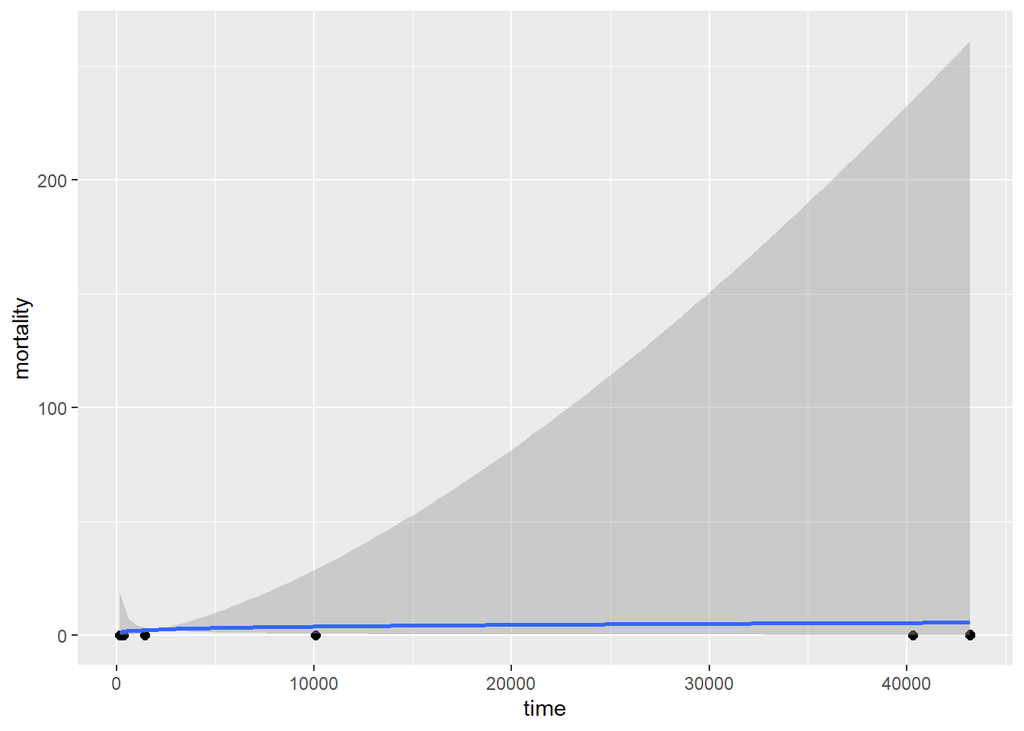

```r
plot(conditional_effects(brm.intercept.test),points=T)
```

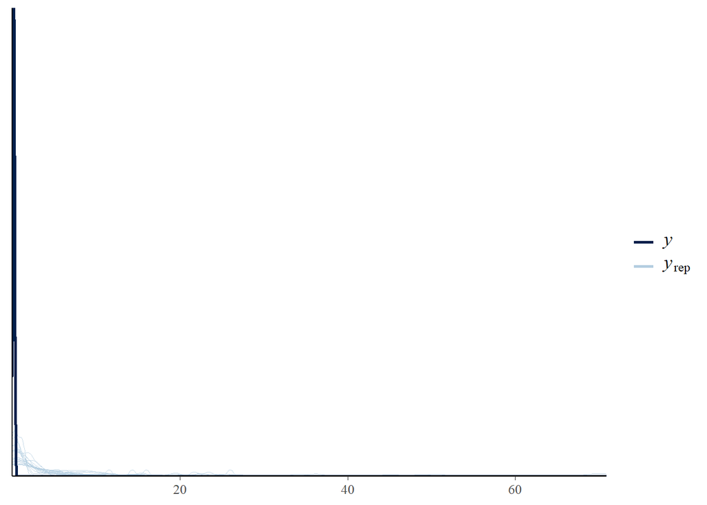

```r
pp_check(brm.intercept.test, ndraws = 20)
```

Well the intercept did get closer to 0 but it is still huge compared to the values in the data (0.something). Pictures are horrible again…

Not even sure should I set the intercept to zero with some deviation, or should I get the intercept in the summary to be zero…

According to article (see https://rpubs.com/jwesner/gamma_glm) “The intercept represents the mean of logy when x is zero. so a value of 0.01 for the intercept would indicate a mean of exp(0.01) = 1.01” –> They used a model y ~ x, so it won’t probably work as planned - Is it in this case something like mean of logy when logx is 0…? Which happens when x = 1? This is confusing. –> exp(anything inside) will be greater than zero… But I cannot figure out what that means in this mess that I have created :D –> Should probably make the y ~ x to work first …

Trying if bigger numbers in y could help to solve the problem with y ~ x:

```r
brm.force.zero <- brm(mortality_percentage ~ (time),
             brmsfamily(family = "Gamma", link = "log"),
             data = all_data,
             chains = 4,
             cores = getOption("mc.cores", 1),
             iter = 3000, warmup = 1500, thin = 5,

             prior =  c(prior(normal(0, 2), "b"),
                        prior(normal(0, 0.1), "Intercept"),
                        prior(gamma(0.01,0.01),class="shape")))
```

```
##
##
## Error in sampler$call_sampler(args_list[[i]]) : Initialization failed.
## character(0)
## [1] "error occurred during calling the sampler; sampling not done"
```

It didn’t work (surprise :D).

Trying other things done in the article even though the y ~ log(x) is rather questionable thing to do, especially when I’m confused about how it really works :D

Anyway. Products used in blood transfusion and the article in which the data is gathered may have some effect on this system, so trying to take it in consideration.

```r
brm.2 <- brm(mortality ~ log(time) + (1|products),
             brmsfamily(family = "Gamma", link = "log"),
             data = all_data,
             chains = 4,
             cores = getOption("mc.cores", 1),
             iter = 3000, warmup = 1500, thin = 5,

             prior =  c(prior(normal(0, 2), "b"),
                        prior(normal(0, 2), "Intercept"),
                        prior(gamma(0.01,0.01),class="shape")))
summary(brm.2)
```

```
##  Family: gamma
##   Links: mu = log; shape = identity
## Formula: mortality ~ log(time) + (1 | products)
##    Data: all_data (Number of observations: 17)
##   Draws: 4 chains, each with iter = 3000; warmup = 1500; thin = 5;
##          total post-warmup draws = 1200
##
## Group-Level Effects:
## ~products (Number of levels: 3)
##               Estimate Est.Error l-95% CI u-95% CI Rhat Bulk_ESS Tail_ESS
## sd(Intercept)     0.37      0.41     0.01     1.58 1.01      409      394
##
## Population-Level Effects:
##           Estimate Est.Error l-95% CI u-95% CI Rhat Bulk_ESS Tail_ESS
## Intercept    -3.18      0.54    -4.17    -2.04 1.00      832      542
## logtime       0.18      0.06     0.06     0.31 1.00      971      940
##
## Family Specific Parameters:
##       Estimate Est.Error l-95% CI u-95% CI Rhat Bulk_ESS Tail_ESS
## shape     5.15      1.83     2.22     9.12 1.00      937     1097
##
## Draws were sampled using sampling(NUTS). For each parameter, Bulk_ESS
## and Tail_ESS are effective sample size measures, and Rhat is the potential
## scale reduction factor on split chains (at convergence, Rhat = 1).
```

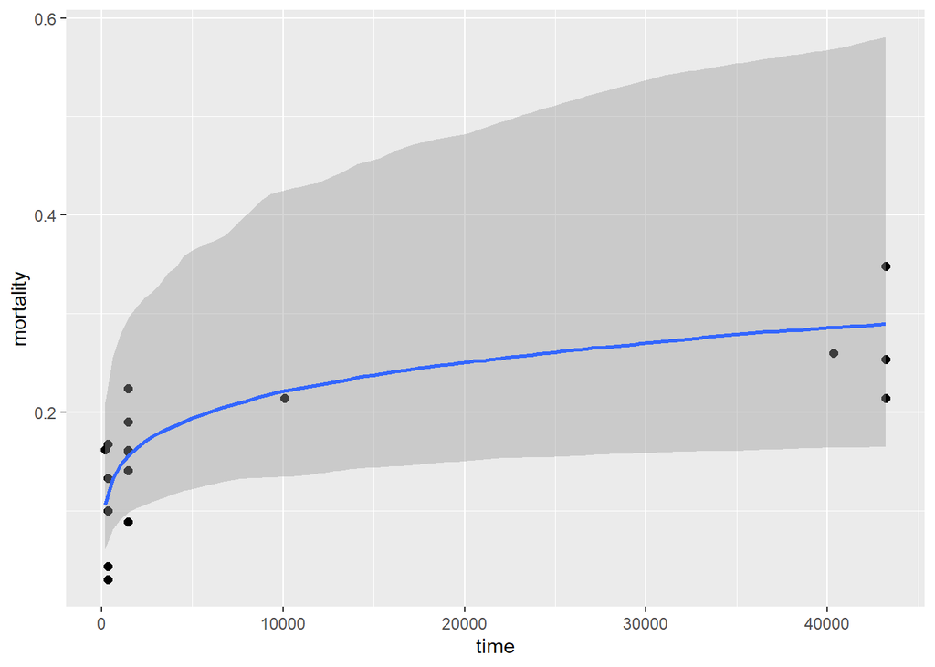

```r
plot(conditional_effects(brm.2),points=T)
```

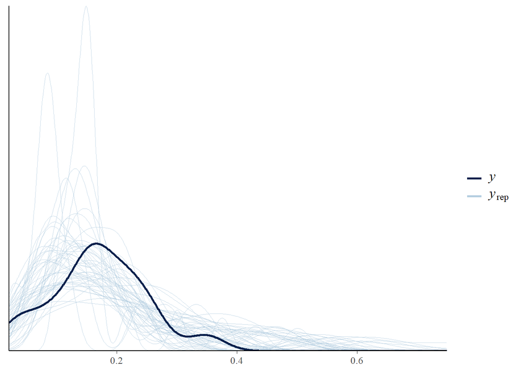

```r
pp_check(brm.2, ndraws = 50)
```

```r
brm.3 <- brm(mortality ~ log(time) + (1|ArticleAbbr),
             brmsfamily(family = "Gamma", link = "log"),
             data = all_data,
             chains = 4, #specify the number of Markov chains
             cores = getOption("mc.cores", 1),
             iter = 3000, warmup = 1500, thin = 5,

             prior =  c(prior(normal(0, 2), "b"),
                        prior(normal(0, 2), "Intercept"),
                        prior(gamma(0.01,0.01),class="shape")))
summary(brm.3)
```

```
##  Family: gamma
##   Links: mu = log; shape = identity
## Formula: mortality ~ log(time) + (1 | ArticleAbbr)
##    Data: all_data (Number of observations: 17)
##   Draws: 4 chains, each with iter = 3000; warmup = 1500; thin = 5;
##          total post-warmup draws = 1200
##
## Group-Level Effects:
## ~ArticleAbbr (Number of levels: 7)
##               Estimate Est.Error l-95% CI u-95% CI Rhat Bulk_ESS Tail_ESS
## sd(Intercept)     0.33      0.22     0.02     0.83 1.00      833     1136
##
## Population-Level Effects:
##           Estimate Est.Error l-95% CI u-95% CI Rhat Bulk_ESS Tail_ESS
## Intercept    -3.30      0.47    -4.17    -2.42 1.00     1185     1096
## logtime       0.19      0.06     0.08     0.30 1.00     1265     1077
##
## Family Specific Parameters:
##       Estimate Est.Error l-95% CI u-95% CI Rhat Bulk_ESS Tail_ESS
## shape     7.08      3.29     2.37    14.86 1.00     1105      888
##
## Draws were sampled using sampling(NUTS). For each parameter, Bulk_ESS
## and Tail_ESS are effective sample size measures, and Rhat is the potential
## scale reduction factor on split chains (at convergence, Rhat = 1).
```

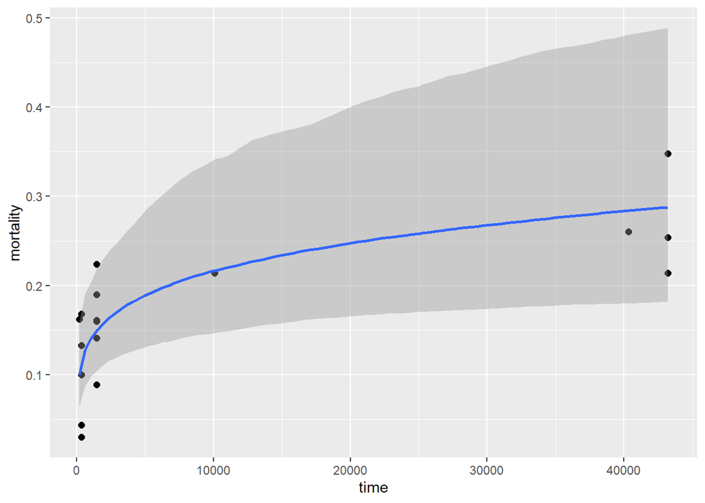

```r
plot(conditional_effects(brm.3),points=T)
```

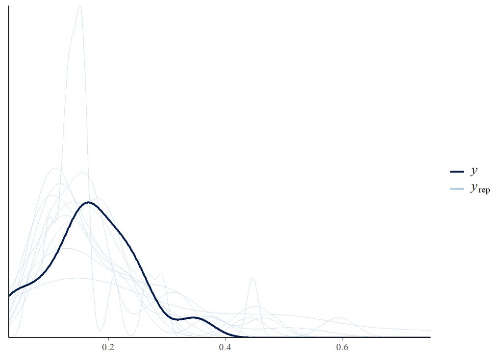

```r
pp_check(brm.3, ndraws = 10)
```

```r
brm.4 <- brm(mortality ~ log(time) + (1|products) + (1|ArticleAbbr),
             brmsfamily(family = "Gamma", link = "log"),
             data = all_data,
             chains = 4, #specify the number of Markov chains
             cores = getOption("mc.cores", 1),
             iter = 3000, warmup = 1500, thin = 5,

             prior =  c(prior(normal(0, 2), "b"),
                        prior(normal(0, 2), "Intercept"),
                        prior(gamma(0.01,0.01),class="shape")))
summary(brm.4)
```

```
##  Family: gamma
##   Links: mu = log; shape = identity
## Formula: mortality ~ log(time) + (1 | products) + (1 | ArticleAbbr)
##    Data: all_data (Number of observations: 17)
##   Draws: 4 chains, each with iter = 3000; warmup = 1500; thin = 5;
##          total post-warmup draws = 1200
##
## Group-Level Effects:
## ~ArticleAbbr (Number of levels: 7)
##               Estimate Est.Error l-95% CI u-95% CI Rhat Bulk_ESS Tail_ESS
## sd(Intercept)     0.39      0.27     0.02     1.02 1.00      791      892
##
## ~products (Number of levels: 3)
##               Estimate Est.Error l-95% CI u-95% CI Rhat Bulk_ESS Tail_ESS
## sd(Intercept)     0.46      0.47     0.01     1.79 1.00      812      657
##
## Population-Level Effects:
##           Estimate Est.Error l-95% CI u-95% CI Rhat Bulk_ESS Tail_ESS
## Intercept    -3.32      0.58    -4.49    -2.14 1.00      742      666
## logtime       0.20      0.06     0.09     0.32 1.00     1100     1132
##
## Family Specific Parameters:
##       Estimate Est.Error l-95% CI u-95% CI Rhat Bulk_ESS Tail_ESS
## shape     7.18      3.27     2.76    15.46 1.00      976      615
##
## Draws were sampled using sampling(NUTS). For each parameter, Bulk_ESS
## and Tail_ESS are effective sample size measures, and Rhat is the potential
## scale reduction factor on split chains (at convergence, Rhat = 1).
```

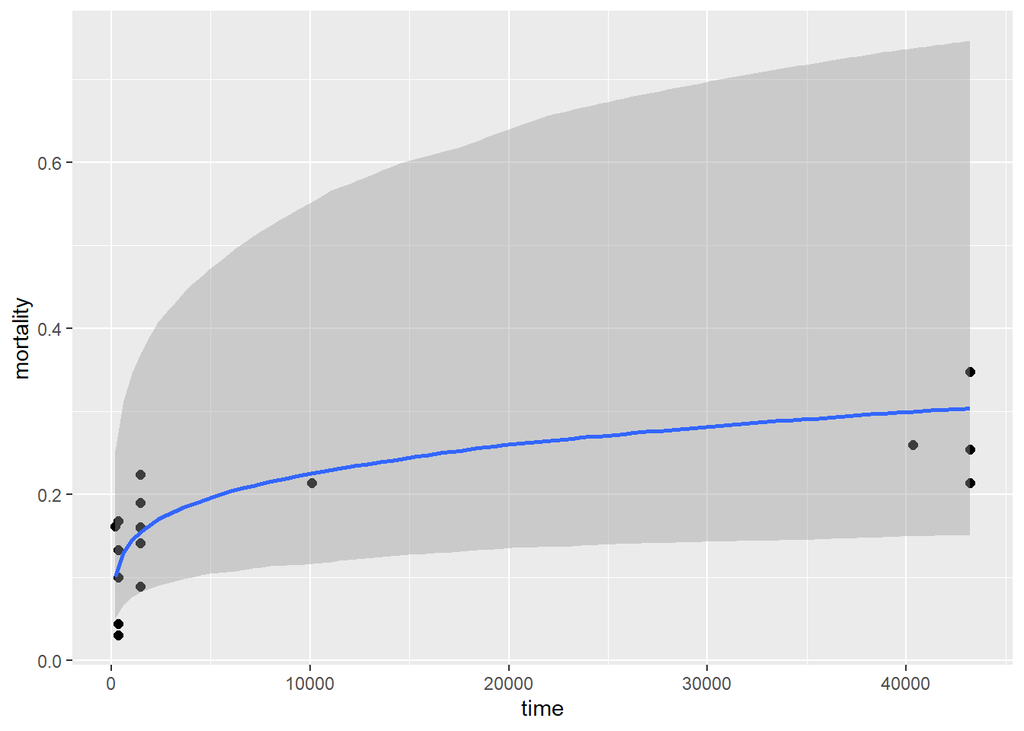

```r
plot(conditional_effects(brm.4),points=T)
```

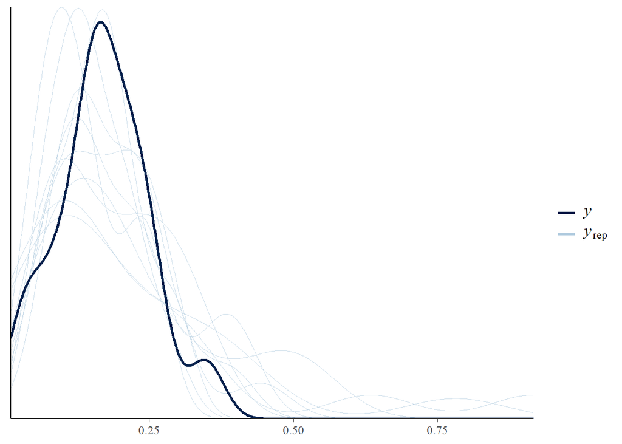

```r
pp_check(brm.4, ndraws = 10)
```

```r
brm.5 <- brm(mortality ~ log(time) + (1 + log(time)|products) + (1 + log(time)|ArticleAbbr),
             brmsfamily(family = "Gamma", link = "log"),
             data = all_data,
             chains = 4, #specify the number of Markov chains
             cores = getOption("mc.cores", 1),
             iter = 3000, warmup = 1500, thin = 5,

             prior =  c(prior(normal(0, 2), "b"),
                        prior(normal(0, 2), "Intercept"),
                        prior(gamma(0.01,0.01),class="shape")))
loo(brm.1, brm.2, brm.3, brm.4, brm.5, cores = getOption("mc.cores", 1))
```

```
## Output of model 'brm.1':
##
## Computed from 1200 by 17 log-likelihood matrix
##
##          Estimate  SE
## elpd_loo     19.8 2.6
## p_loo         2.8 1.2
## looic       -39.7 5.2
## ------
## Monte Carlo SE of elpd_loo is 0.1.
##
## All Pareto k estimates are good (k < 0.5).
## See help('pareto-k-diagnostic') for details.
##
## Output of model 'brm.2':
##
## Computed from 1200 by 17 log-likelihood matrix
##
##          Estimate  SE
## elpd_loo     19.1 2.5
## p_loo         3.6 1.2
## looic       -38.2 5.0
## ------
## Monte Carlo SE of elpd_loo is 0.1.
##
## Pareto k diagnostic values:
##                          Count Pct.    Min. n_eff
## (-Inf, 0.5]   (good)     15    88.2%   190
##  (0.5, 0.7]   (ok)        2    11.8%   400
##    (0.7, 1]   (bad)       0     0.0%   <NA>
##    (1, Inf)   (very bad)  0     0.0%   <NA>
##
## All Pareto k estimates are ok (k < 0.7).
## See help('pareto-k-diagnostic') for details.
##
## Output of model 'brm.3':
##
## Computed from 1200 by 17 log-likelihood matrix
##
##          Estimate  SE
```

[output cut: 44 more lines]

```
## Pareto k diagnostic values:
##                          Count Pct.    Min. n_eff
## (-Inf, 0.5]   (good)     2     11.8%   316
##  (0.5, 0.7]   (ok)       6     35.3%   188
##    (0.7, 1]   (bad)      8     47.1%   18
##    (1, Inf)   (very bad) 1      5.9%   16
## See help('pareto-k-diagnostic') for details.
##
## Model comparisons:
##       elpd_diff se_diff
## brm.5  0.0       0.0
## brm.3 -2.2       1.6
## brm.4 -2.4       1.4
## brm.1 -2.4       2.1
## brm.2 -3.1       1.9
```

```r
summary(brm.5)
```

```
##  Family: gamma
##   Links: mu = log; shape = identity
## Formula: mortality ~ log(time) + (1 + log(time) | products) + (1 + log(time) | ArticleAbbr)
##    Data: all_data (Number of observations: 17)
##   Draws: 4 chains, each with iter = 3000; warmup = 1500; thin = 5;
##          total post-warmup draws = 1200
##
## Group-Level Effects:
## ~ArticleAbbr (Number of levels: 7)
##                        Estimate Est.Error l-95% CI u-95% CI Rhat Bulk_ESS
## sd(Intercept)              0.82      0.59     0.05     2.23 1.00      577
## sd(logtime)                0.08      0.07     0.00     0.25 1.00      793
## cor(Intercept,logtime)    -0.44      0.55    -0.99     0.86 1.00      860
##                        Tail_ESS
## sd(Intercept)               973
## sd(logtime)                 755
## cor(Intercept,logtime)     1014
##
## ~products (Number of levels: 3)
##                        Estimate Est.Error l-95% CI u-95% CI Rhat Bulk_ESS
## sd(Intercept)              1.25      1.02     0.05     3.99 1.00      829
## sd(logtime)                0.18      0.17     0.01     0.61 1.00      683
## cor(Intercept,logtime)    -0.32      0.57    -0.99     0.86 1.01      325
##                        Tail_ESS
## sd(Intercept)               804
## sd(logtime)                 811
## cor(Intercept,logtime)      251
##
## Population-Level Effects:
##           Estimate Est.Error l-95% CI u-95% CI Rhat Bulk_ESS Tail_ESS
## Intercept    -3.30      0.95    -5.29    -1.45 1.01      364      312
## logtime       0.24      0.12     0.02     0.51 1.00      475      542
##
## Family Specific Parameters:
##       Estimate Est.Error l-95% CI u-95% CI Rhat Bulk_ESS Tail_ESS
## shape    13.44      8.25     3.12    32.82 1.01      439      609
##
## Draws were sampled using sampling(NUTS). For each parameter, Bulk_ESS
## and Tail_ESS are effective sample size measures, and Rhat is the potential
## scale reduction factor on split chains (at convergence, Rhat = 1).
```

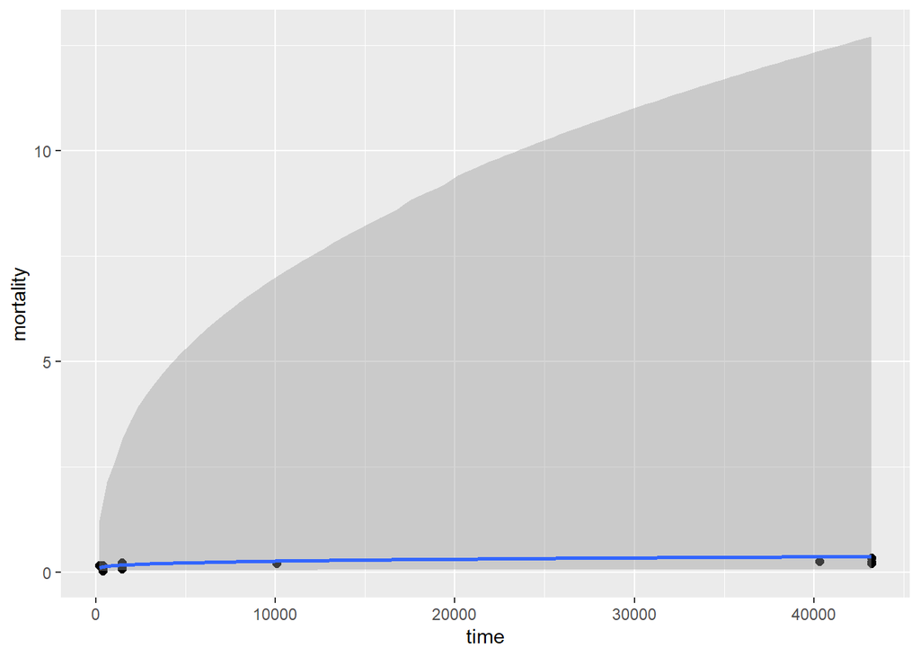

```r
plot(conditional_effects(brm.5),points=T)
```

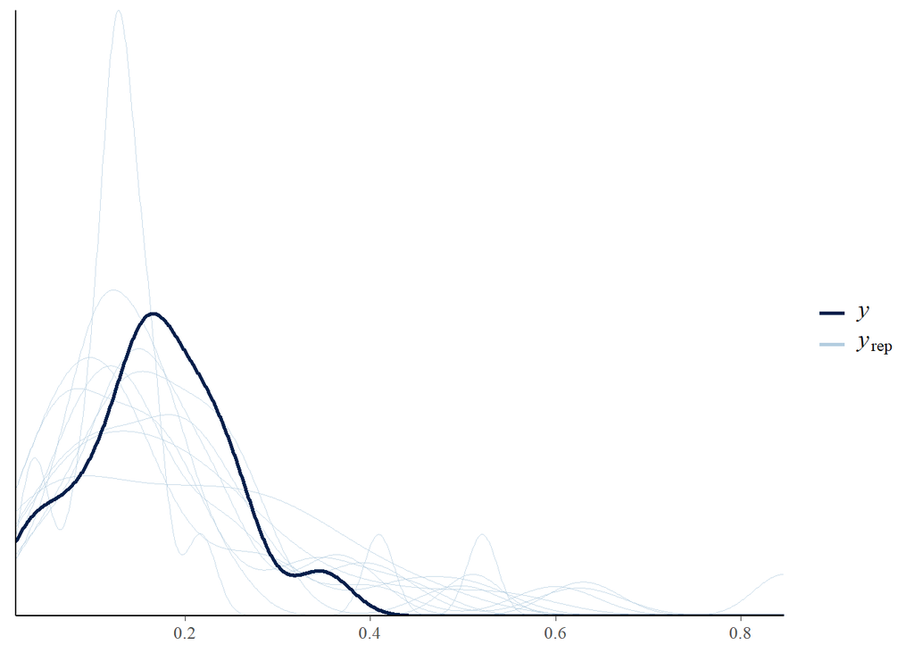

```r
pp_check(brm.5, ndraws = 10)
```

Well. Many plots and summaries later I guess I’m not able to say anything about the results since the y ~log(x) is probably wrong way to approach this. And the fit is quite bad, no matter what I do :D

Because I’m getting a bit desperate, I’m trying to change the time to hours to see if it helps at all. Changing also decimal numbers to percents… It shouldn’t help but I’ll try anything now.

```r
df <- read_excel("C:\\Projektit\\whole_blood_research\\excel\\Emergencyprocess_PHBT_splines.xlsx", sheet = "all_hours")
all_data <- filter(df, products == "O-negative PRBCs" | products == "LTOWB" | products == "plasma and/or RBCs")

# Trying another way to do this
brm_glm_reg <- brm(mortality_percentage~log(time), data=all_data, family=Gamma(link="log"),
          prior=c(prior(normal(0,2),class="Intercept"),
                  prior(normal(0, 2),class="b"),
                  prior(gamma(0.01,0.01),class="shape")),
          chains=4,iter=1000, cores=1)
summary(brm_glm_reg)
```

```
##  Family: gamma
##   Links: mu = log; shape = identity
## Formula: mortality_percentage ~ log(time)
##    Data: all_data (Number of observations: 17)
##   Draws: 4 chains, each with iter = 1000; warmup = 500; thin = 1;
##          total post-warmup draws = 2000
##
## Population-Level Effects:
##           Estimate Est.Error l-95% CI u-95% CI Rhat Bulk_ESS Tail_ESS
## Intercept     2.14      0.24     1.67     2.66 1.00     1431     1183
## logtime       0.18      0.06     0.06     0.29 1.00     1317     1251
##
## Family Specific Parameters:
##       Estimate Est.Error l-95% CI u-95% CI Rhat Bulk_ESS Tail_ESS
## shape     5.17      1.91     2.27     9.51 1.00     1297     1341
##
## Draws were sampled using sampling(NUTS). For each parameter, Bulk_ESS
## and Tail_ESS are effective sample size measures, and Rhat is the potential
## scale reduction factor on split chains (at convergence, Rhat = 1).
```

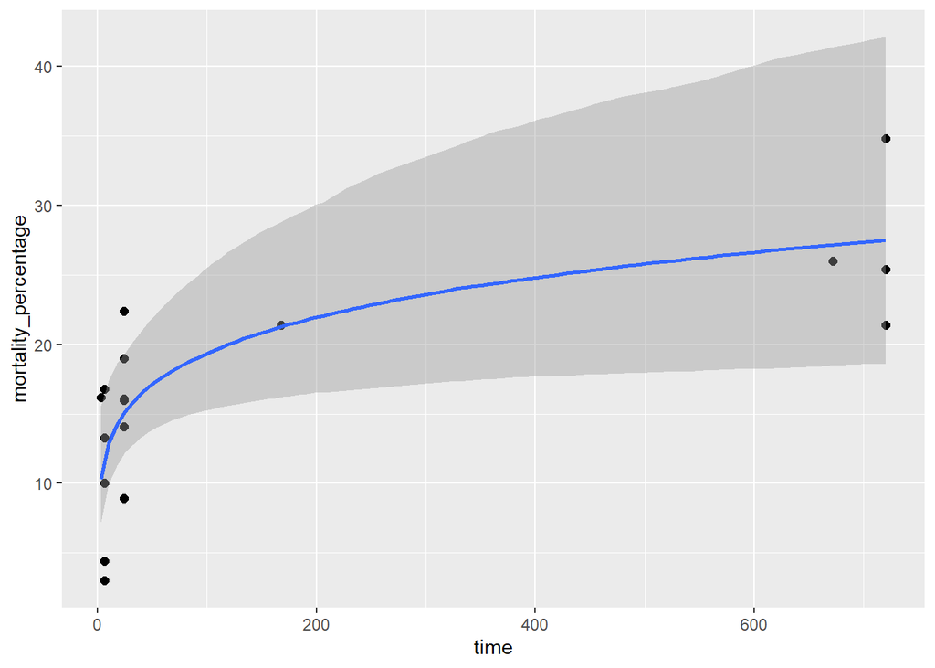

```r
plot(conditional_effects(brm_glm_reg),points=T)
```

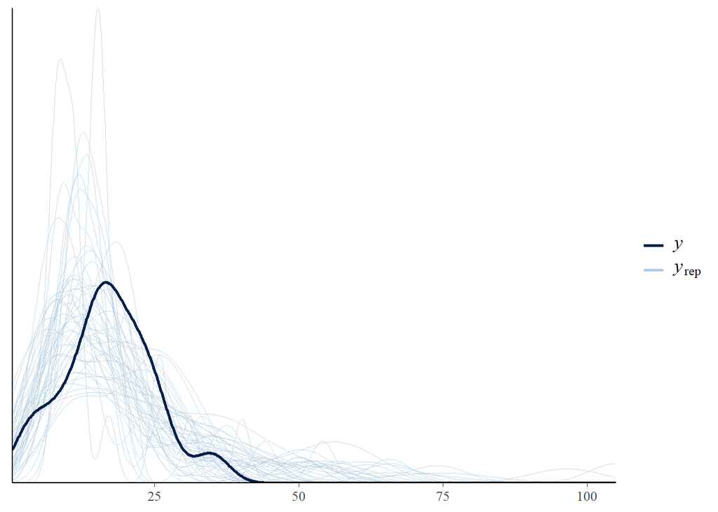

```r
pp_check(brm_glm_reg, ndraws = 50)
```

This could probably be forced to zero…? Let’s try.

```r
brm_glm_reg_zero <- brm(mortality_percentage~0+0+log(time), data=all_data, family=Gamma(link="log"),
          prior=c(#prior(normal(0,2),class="Intercept"),
                  prior(normal(0, 2),class="b"),
                  prior(gamma(0.01,0.01),class="shape")),
          chains=4,iter=1000, cores=1)
summary(brm_glm_reg_zero)
```

```
##  Family: gamma
##   Links: mu = log; shape = identity
## Formula: mortality_percentage ~ 0 + 0 + log(time)
##    Data: all_data (Number of observations: 17)
##   Draws: 4 chains, each with iter = 1000; warmup = 500; thin = 1;
##          total post-warmup draws = 2000
##
## Population-Level Effects:
##         Estimate Est.Error l-95% CI u-95% CI Rhat Bulk_ESS Tail_ESS
## logtime     0.79      0.09     0.63     0.98 1.00     1460     1335
##
## Family Specific Parameters:
##       Estimate Est.Error l-95% CI u-95% CI Rhat Bulk_ESS Tail_ESS
## shape     0.78      0.23     0.40     1.28 1.00     1336     1257
##
## Draws were sampled using sampling(NUTS). For each parameter, Bulk_ESS
## and Tail_ESS are effective sample size measures, and Rhat is the potential
## scale reduction factor on split chains (at convergence, Rhat = 1).
```

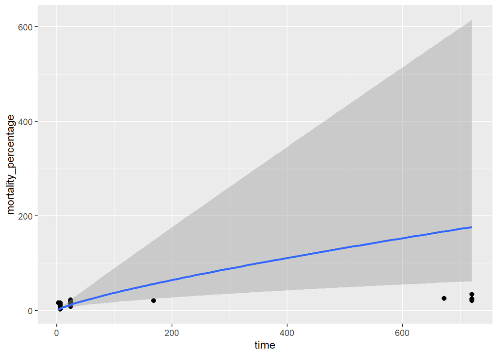

```r
plot(conditional_effects(brm_glm_reg_zero),points=T)
```

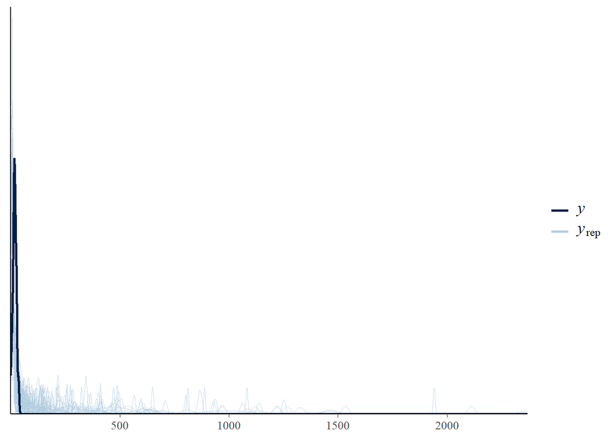

```r
pp_check(brm_glm_reg_zero, ndraws = 100)
```

Well. This is just going in worse direction, so let’s try y ~ x again :D

```r
brm_glm_reg2<- brm(mortality_percentage~(time), data=all_data, family=Gamma(link="log"),
          prior=c(prior(normal(0,2),class="Intercept"),
                  prior(normal(0, 2),class="b"),
                  prior(gamma(0.01,0.01),class="shape")),
          chains=4,iter=1000, cores=1)
```

Some pretty bad sounding errors, but it did something!

```r
summary(brm_glm_reg2)
```

```
##  Family: gamma
##   Links: mu = log; shape = identity
## Formula: mortality_percentage ~ (time)
##    Data: all_data (Number of observations: 17)
##   Draws: 4 chains, each with iter = 1000; warmup = 500; thin = 1;
##          total post-warmup draws = 2000
##
## Population-Level Effects:
##           Estimate Est.Error l-95% CI u-95% CI Rhat Bulk_ESS Tail_ESS
## Intercept    30.32     48.09     2.34   113.87 1.76        6       11
## time         -0.15      0.26    -0.61     0.00 1.62        7       11
##
## Family Specific Parameters:
##       Estimate Est.Error l-95% CI u-95% CI Rhat Bulk_ESS Tail_ESS
## shape     3.12      1.98     0.32     7.06 1.75        6       11
##
## Draws were sampled using sampling(NUTS). For each parameter, Bulk_ESS
## and Tail_ESS are effective sample size measures, and Rhat is the potential
## scale reduction factor on split chains (at convergence, Rhat = 1).
```

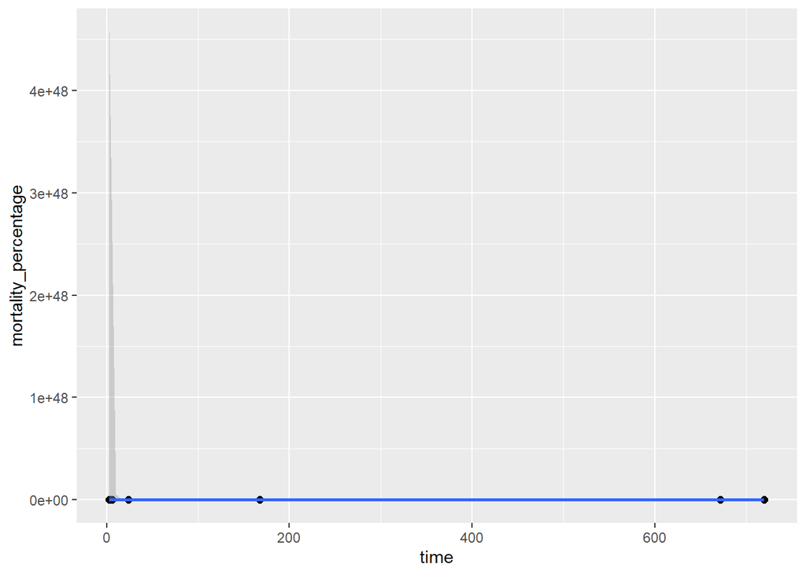

```r
plot(conditional_effects(brm_glm_reg2),points=T)
```

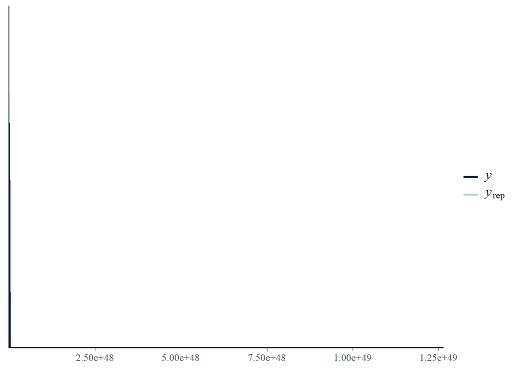

```r
pp_check(brm_glm_reg2, ndraws = 50)
```

Well it didn’t help or the errors are trying to say that this will produce a bit unreliable results… The diamond data used log(y)~log(x), which could work for these data points (mortality_percentage is greater than 1… I don’t really know if that really matters or not :D)

```r
brm_glm_reg3<- brm(log(mortality_percentage)~log(time), data=all_data, family=Gamma(link="log"),
          prior=c(prior(normal(0,2),class="Intercept"),
                  prior(normal(0, 2),class="b"),
                  prior(gamma(0.01,0.01),class="shape")),
          chains=4,iter=1000, cores=1)
summary(brm_glm_reg3)
```

```
##  Family: gamma
##   Links: mu = log; shape = identity
## Formula: log(mortality_percentage) ~ log(time)
##    Data: all_data (Number of observations: 17)
##   Draws: 4 chains, each with iter = 1000; warmup = 500; thin = 1;
##          total post-warmup draws = 2000
##
## Population-Level Effects:
##           Estimate Est.Error l-95% CI u-95% CI Rhat Bulk_ESS Tail_ESS
## Intercept     0.71      0.13     0.45     0.97 1.00     1289      713
## logtime       0.08      0.03     0.01     0.14 1.00     1126     1037
##
## Family Specific Parameters:
##       Estimate Est.Error l-95% CI u-95% CI Rhat Bulk_ESS Tail_ESS
## shape    17.81      6.40     7.42    32.84 1.00     1058     1225
##
## Draws were sampled using sampling(NUTS). For each parameter, Bulk_ESS
## and Tail_ESS are effective sample size measures, and Rhat is the potential
## scale reduction factor on split chains (at convergence, Rhat = 1).
```

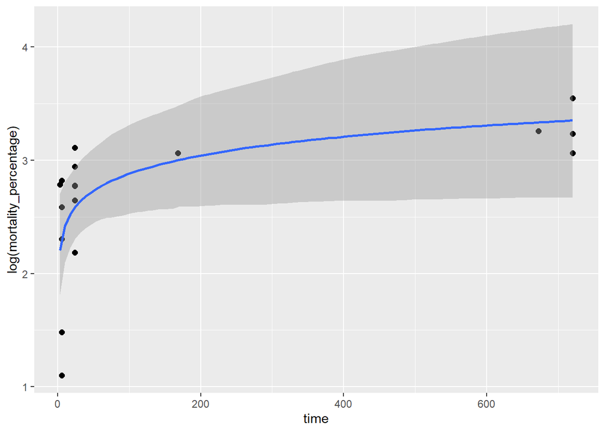

```r
plot(conditional_effects(brm_glm_reg3),points=T)
```

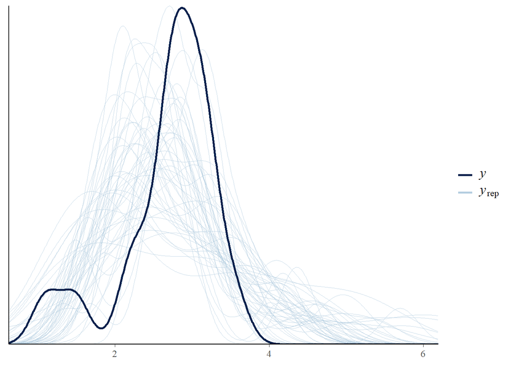

```r
pp_check(brm_glm_reg3, ndraws = 50)
```

If I didn’t know how to approach interpreting the y ~log(x) and the results, this is even more confusing. Maybe I’ll just ask someone who knows how this thing works… At least it did something.